# Adding a regression line on a ggplot2

# Setup

This short post will show how to add a regression line to a [ggplot2](https://ggplot2.tidyverse.org/) chart. We start by loading in the `USpop` data found in the second lab.

```r
USpop <- read.csv("USpop.csv")
```

Next, we create a simple linear regression model

```r
my_fit <- lm(Population ~ Year, data = USpop)

my_fit
```

```
Call:
lm(formula = Population ~ Year, data = USpop)

Coefficients:
(Intercept)         Year
   -2480.70         1.36
```

Let us start with a simple scatter chart using ggplot2

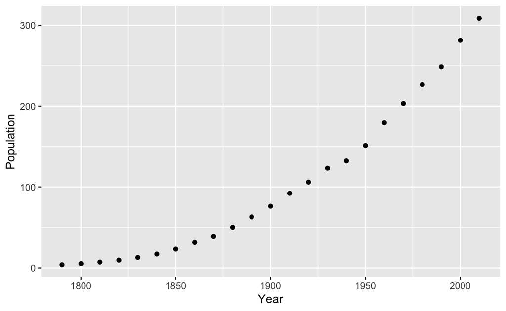

```r
library(ggplot2)

ggplot(USpop, aes(Year, Population)) +
  geom_point()
```

Adding a regression line to this chart can be done in a couple of different ways.

# Using `geom_smooth()`

The first way is by far the most simple. Using `geom_smooth()` fits a line directly to the data inside ggplot itself, if we specify `method = "lm` and `formula = y ~ x` then we force that line to a simple linear regression. Setting `se = FALSE` hides the confidence intervals.

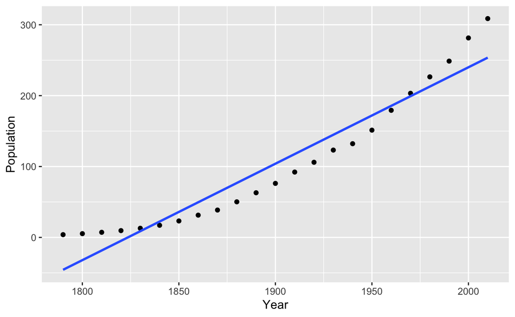

```r
ggplot(USpop, aes(Year, Population)) +
  geom_point() +
  geom_smooth(method = "lm", formula = y ~ x, se = FALSE)
```

This method while pleasing doesn’t answer the question at hand. It doesn’t let us add our already fitted model, but instead fits a model itself.

# using `broom::augment()`

You can use the broom package to extract various information from the model fit.

```r
library(broom)
augment(my_fit)
```

```
# A tibble: 23 x 8
   Population  Year .fitted .resid .std.resid   .hat .sigma .cooksd
        <dbl> <int>   <dbl>  <dbl>      <dbl>  <dbl>  <dbl>   <dbl>
 1        3.9  1790  -45.7   49.6       1.94  0.163    26.0 0.365
 2        5.3  1800  -32.1   37.4       1.44  0.142    27.2 0.173
 3        7.2  1810  -18.5   25.7       0.980 0.124    28.0 0.0676
 4        9.6  1820   -4.85  14.5       0.547 0.107    28.5 0.0179
 5       12.9  1830    8.75   4.15      0.156 0.0919   28.6 0.00123
 6       17.1  1840   22.4   -5.25     -0.196 0.0791   28.6 0.00164
 7       23.2  1850   36.0  -12.8      -0.472 0.0682   28.5 0.00816
 8       31.4  1860   49.6  -18.2      -0.669 0.0593   28.4 0.0141
 9       38.6  1870   63.2  -24.6      -0.902 0.0524   28.1 0.0225
10       50.2  1880   76.8  -26.6      -0.973 0.0474   28.0 0.0236
# … with 13 more rows
```

Using this data along with `geom_line()` allows us to all a fitted line on top of our ggplot

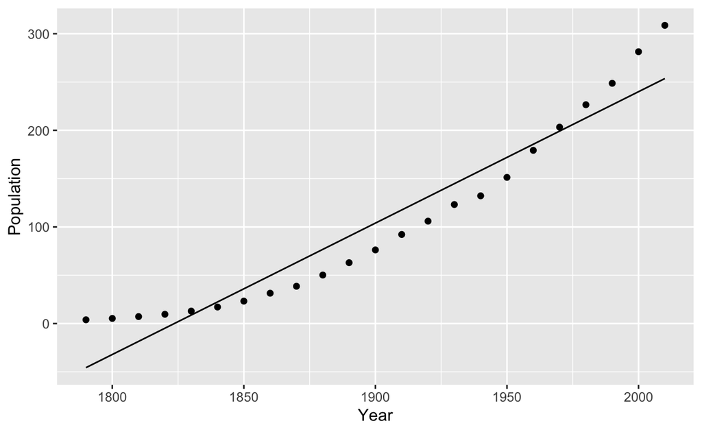

```r
ggplot(USpop, aes(Year, Population)) +
  geom_point() +
  geom_line(data = augment(my_fit),
            aes(x = Year, y = .fitted))
```

The main downside to this way is that it does not easily extrapolate outside the range so we zoom out the line doesn’t expand

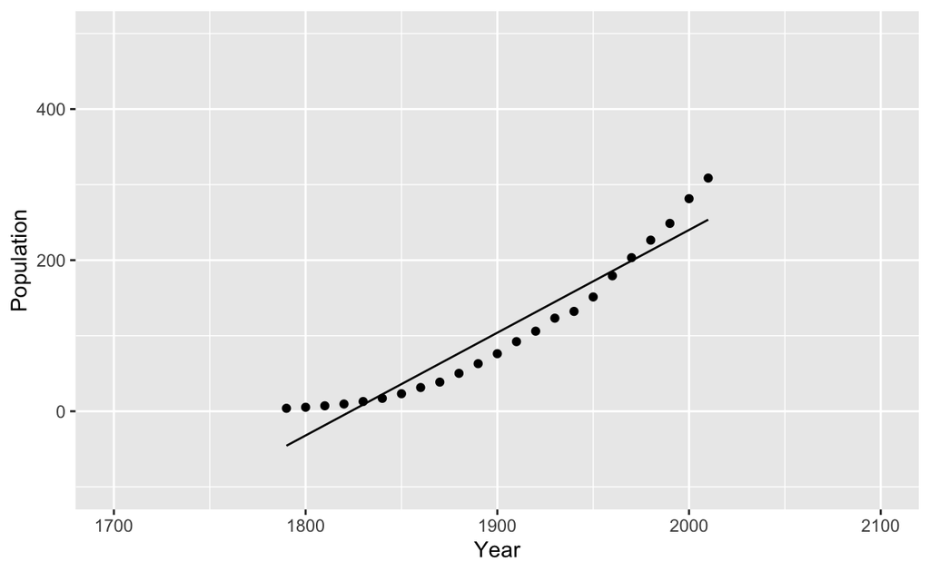

```r
ggplot(USpop, aes(Year, Population)) +
  geom_point() +
  geom_line(data = augment(my_fit),
            aes(x = Year, y = .fitted)) +
  lims(x = c(1700, 2100), y = c(-100, 500))
```

# `coef()` and `geom_abline()`

Lastly, we can extract the parameters estimates directly with `coef()` and use these to add a single line with `geom_abline()`

```r
my_coef <- coef(my_fit)
my_coef
```

```
 (Intercept)         Year
-2480.701976     1.360356
```

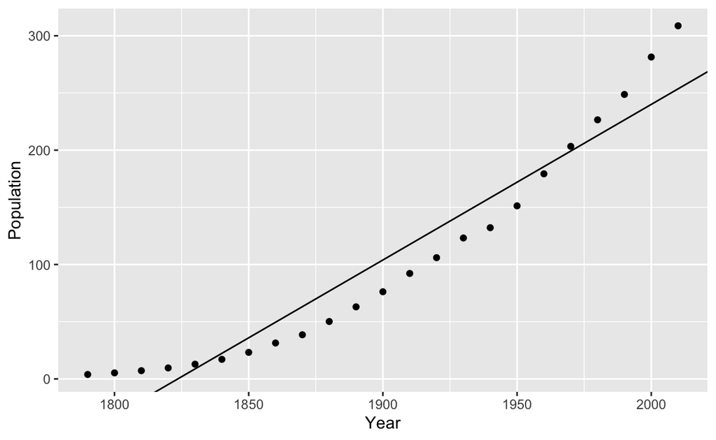

```r
ggplot(USpop, aes(Year, Population)) +
  geom_point() +
  geom_abline(intercept = my_coef[1], slope = my_coef[2])
```

Since `geom_abline()` add a line you can zoom out and still see the line

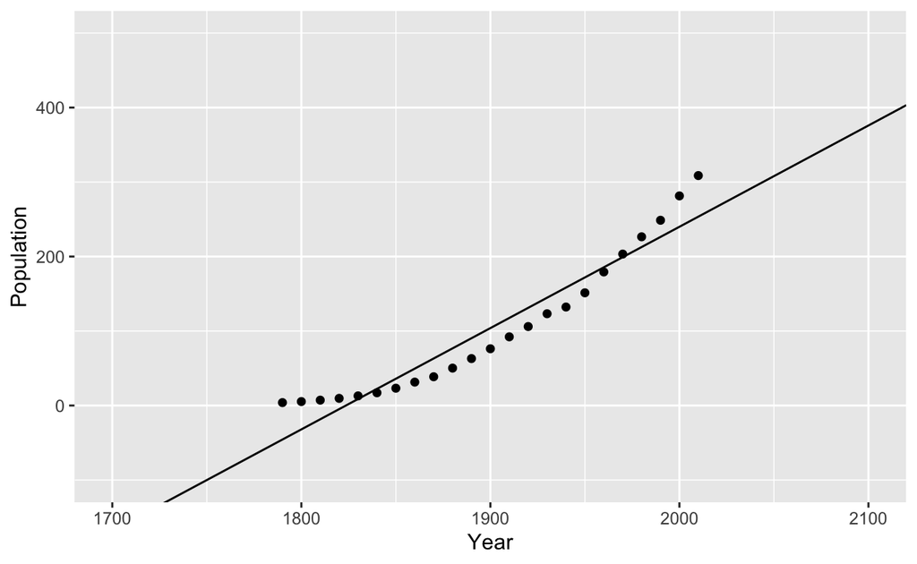

```r
ggplot(USpop, aes(Year, Population)) +
  geom_point() +
  geom_abline(intercept = my_coef[1], slope = my_coef[2]) +
  lims(x = c(1700, 2100), y = c(-100, 500))
```